# U4_Es6

Mattia Piazzon

2024-05-14

# Esercizio 6

## Testo

I dati contenuti nel file monet.csv riguardano il prezzo di vendita in milioni di dollari di diversi dipinti di Claude Monet. Oltre al prezzo di vendita (price) e l’identificativo numerico del dipinto (id), sono disponibili informazioni circa le dimensioni del dipinto (height e width in pollici), se il dipinto è firmato da Monet o meno (singned) e la casa d’aste in cui il dipinto è stato venduto (house con le tre case identificate da diversi numeri).

## Domande

1. Si valuti la normalità dei prezzi di vendita dei dipinti.
2. Si valuti la normalità dei prezzi di vendita dei dipinti distinti a seconda se siano firmati o meno da Monet.
3. Si rivalutino i due punti precedenti dopo aver trasformato i dati su scala logaritmica.

## Soluzione

### a

```r
monet <- read.csv("monet.csv")
```

Carichiamo la libreria car:

```r
library("car")
```

Vediamo il grafico quantile-quantile dei prezzi dei dipinti:

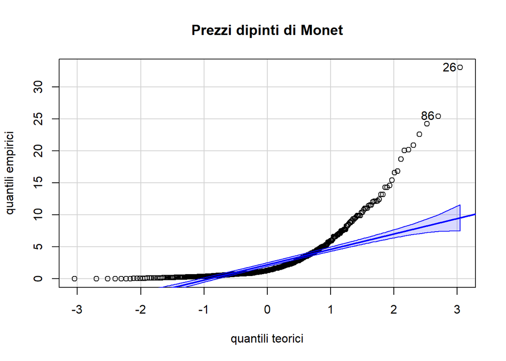

```
## [1] 26 86
```

```r
qqPlot(monet$price, ylab = "quantili empirici", xlab = "quantili teorici", main = "Prezzi dipinti di Monet")
```

Il grafico mostra che i prezzi dei dipinti non sono normalmente distribuiti.

### b

Dividiamo i prezzi dei dipinti in due gruppi: quelli firmati da Monet e quelli non firmati:

```r
x <- with(monet, price[signed == 1])
y <- with(monet, price[signed == 0])
```

Visualizziamo i grafici quantile-quantile dei due gruppi:

```r
## il seguente comando divide la finestra grafica in una riga e due colonne in modo da poter disegnare i due grafici appaiati.
par(mfrow = c(1, 2))
qqPlot(x, ylab = "quantili empirici", xlab = "quantili teorici", main = "Prezzi dipinti firmati")
```

```
## [1] 24 73
```

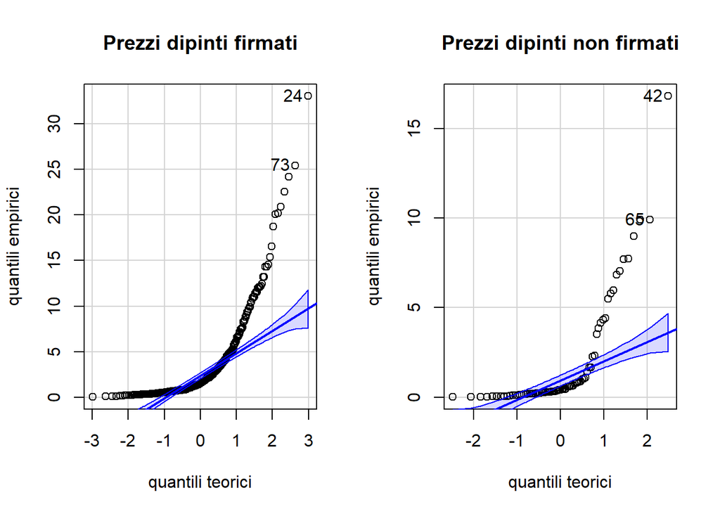

```
## [1] 42 65
```

```r
qqPlot(y, ylab = "quantili empirici", xlab = "quantili teorici", main = "Prezzi dipinti non firmati")
```

```r
## ritorniamo ad una finestra grafica non divisa, ovvero formata da una riga e una colonna
par(mfrow = c(1, 1))
```

Anche i grafici quantile-quantile dei prezzi distinti a seconda della presenza della firma mostrano un’andamento fortemente non normale.

### c

Ripetiamo i grafici precedenti su scala logaritmica. Grafico di tutti i prezzi di vendita:

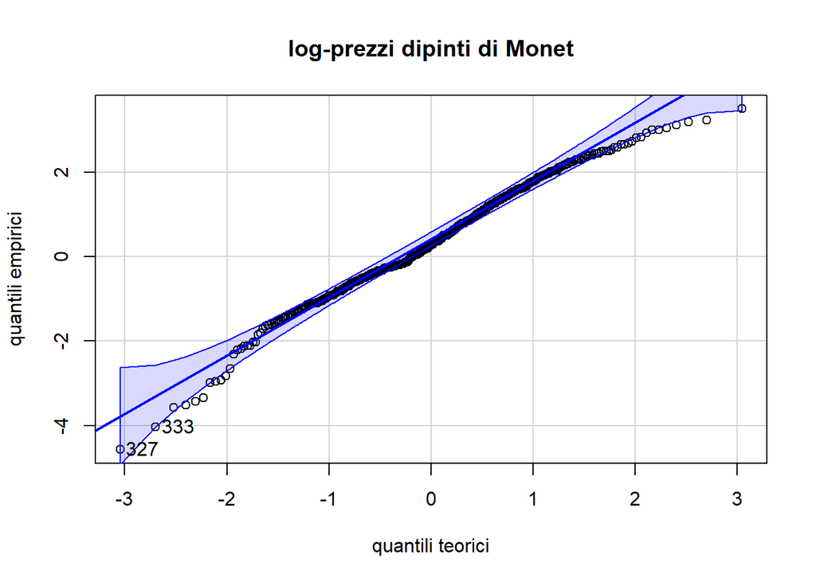

```
## [1] 327 333
```

```r
qqPlot(log(monet$price), ylab = "quantili empirici", xlab = "quantili teorici", main = "log-prezzi dipinti di Monet")
```

La trasformazione logaritmica rende i prezzi dei dipinti più normalmente distribuiti. Grafici dei prezzi distinti a seconda della presenza della firma:

```r
par(mfrow = c(1, 2))
qqPlot(log(x), ylab = "quantili empirici", xlab = "quantili teorici", main = "log-prezzi dipinti firmati")
```

```
## [1] 276  24
```

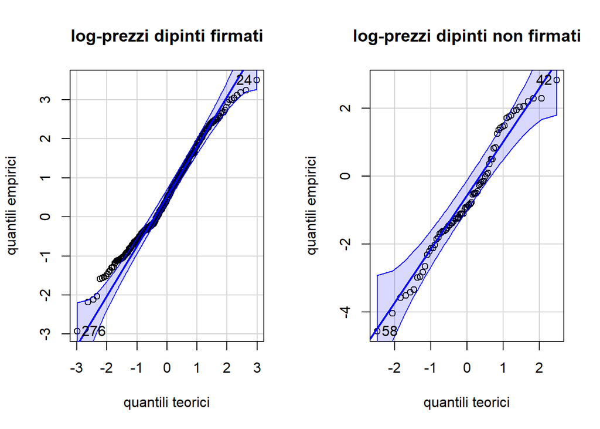

```
## [1] 58 42
```

```r
qqPlot(log(y), ylab = "quantili empirici", xlab = "quantili teorici", main = "log-prezzi dipinti non firmati")
```

```r
par(mfrow = c(1, 1))
```

Il grafico relativo ai dipinti non firmati ci permette di concludere che non possiamo escludere che i prezzi su scala logaritmica siano normalmente distribuiti, mentre per i dipinti firmati gli andamenti sulle due code, e in particolare su quella di sinistra, non sono del tutto soddisfacenti.

# Esercizio 5

## Domande

1. Si valuti se il prezzo di vendita dei dipinti firmati da Claude Monet sia significativamente più alto del prezzo di vendita dei dipinti attribuiti a Claude Monet seppur non firmati dal pittore.
2. Si valuti se la proporzione di dipinti firmati che sono stati battuti dalla prima casa d’aste (house == 1) sia diversa da quella dei dipinti firmati che sono stati battuti dalla seconda casa d’aste (house == 2).

## Soluzione

### a

Sulla base dei risultati dell’esercizio precedente procediamo con l’analisi dei dati sulla scala logaritmica e valutiamo il sistema d’ipotesi:
$$H_0: \mu_x = \mu_y \quad \text{vs} \quad H_1: \mu_x > \mu_y$$
dove $\mu_x$ indica la media del logaritmo del prezzo dei dipinti firmati da Monet e $\mu_y$ indica la media del logaritmo del prezzo dei dipinti non firmati da Monet ma comunque attribuiti a Monet.

```r
monet <-read.csv("monet.csv")
```

Estraiamo la variabile binaria che indica se un dipinto sia firmato o meno:

```r
firmato <- as.factor(monet$signed)
levels(firmato) <- c("No", "Si")
head(firmato)
```

```
## [1] Si Si No Si Si Si
## Levels: No Si
```

Visualizziamo le distribuzioni delle due variabili:

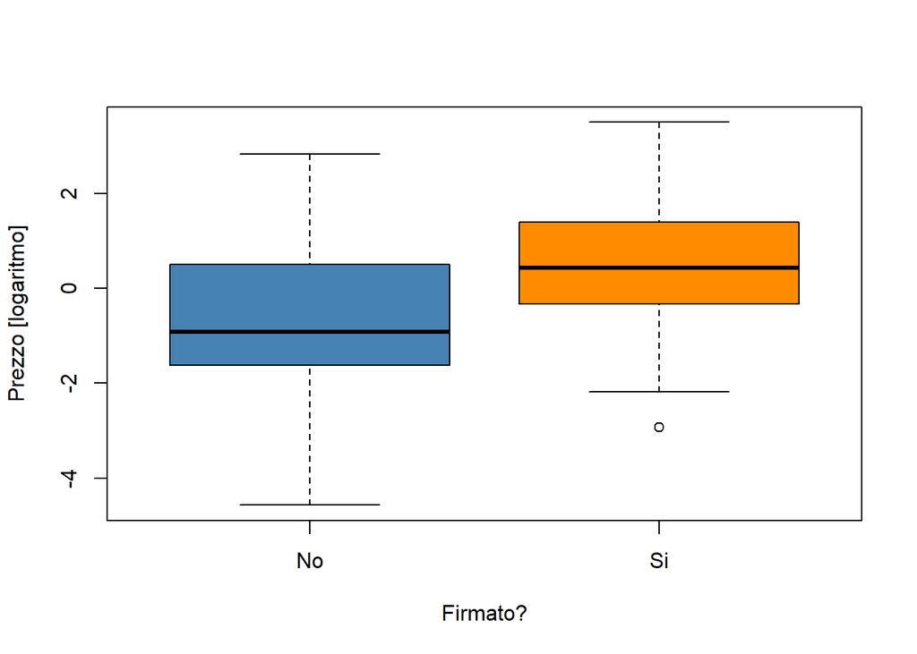

```r
boxplot(log(monet$price) ~ firmato, xlab = "Firmato?", ylab = "Prezzo [logaritmo]", col = c("steelblue", "darkorange"))
```

Il grafico mostra che i prezzi di vendita (su scala logaritmica) sono più alti per i dipinti firmati. Valutiamo ora il sistema d’ipotesi per vedere se la differenza osservata è statisticamente significativa. Per prima cosa costruiamo i vettori che contengono i prezzi su scala logaritmica distinti a seconda della firma:

```r
x <- log(monet$price[firmato == "Si"])
y <- log(monet$price[firmato == "No"])
```

Procediamo con un test di tipo Z:

```r
library("BSDA")
z.test(x, y, sigma.x = sd(x), sigma.y = sd(y), alternative = "greater")
```

```
##
##  Two-sample z-Test
##
## data:  x and y
## z = 5.9926, p-value = 1.032e-09
## alternative hypothesis: true difference in means is greater than 0
## 95 percent confidence interval:
##  0.8796511        NA
## sample estimates:
##  mean of x  mean of y
##  0.5498502 -0.6625911
```

Il valore osservato dalla statistica Z è z = 5.99 che corrisponde ad un livello di significatività osservato pressochè nullo ad indicare un’evidenza molto forte contro l’ipotesi nulla.

### b

Il secondo quesito richiede di valutare il sistema d’ipotesi:
$$H_0: p_x = p_y \quad \text{vs} \quad H_1: p_x \neq p_y$$
dove $p_x$ e $p_y$ indicano le proporzioni di dipinti firmati che sono stati battuti rispettivamente dalla prima e dalla seconda casa d’aste. Costruiamo le variabili binarie corrispondenti alle due case d’aste:

```r
x <- with(monet, signed[house == 1])
y <- with(monet, signed[house == 2])
```

Le proporzioni camponarie dei dipinti firmati battuti dalle due case d’aste sono:

```r
mean(x)
```

```
## [1] 0.8324607
```

```r
mean(y)
```

```
## [1] 0.8604651
```

Valutiamo il sistema di ipotesi con test Z:

```r
sd.x <- sqrt(mean(x) * (1 - mean(x)))
sd.y <- sqrt(mean(y) * (1 - mean(y)))
z.test(x,y, sigma.x = sd.x, sigma.y = sd.y)
```

```
##
##  Two-sample z-Test
##
## data:  x and y
## z = -0.78011, p-value = 0.4353
## alternative hypothesis: true difference in means is not equal to 0
## 95 percent confidence interval:
##  -0.09836273  0.04235396
## sample estimates:
## mean of x mean of y
## 0.8324607 0.8604651
```

Il valore osservato della statistica Z è z = -0.78 che corrisponde ad un livello di significatività osservato pari a 0.44. Non possiamo quindi rifiutare l’ipotesi nulla.

# Esercizio 7

## Soluzione

Verifico la seguente ipotesi:
$$H_0: \lambda = 10 \quad \text{vs} \quad H_1: \lambda \neq 10$$
dove $\lambda$ è il parametro della distribuzione di poisson e rappresenta il numero di errori giornalieri. Calcolo la statistica Z dato che la dimensione campionaria è grande, n = 32, e che essendo una distribuzione di Poisson la varianza è nota e uguale alla media.
$$Z = \frac{\sqrt{n}(\bar{X} - \lambda)}{\sqrt{\lambda}} =
\frac{\sqrt{32}(11.69 - 10)}{\sqrt{10}} = 3.02$$
Ora vedo se con significatività $\alpha = 0.05$ posso rigettare l’ipotesi nulla:

```r
qnorm(0.95)
```

```
## [1] 1.644854
```

Ottengo che 3.02 > 1.64, quindi posso rigettare l’ipotesi nulla.

Calcolo la statistica Z, sapendo per $H_0$ che D = 0:

```r
z = (11.69 - 10.54) / sqrt((11.69/32) + (10.54/37))
z
```

```
## [1] 1.426205
```

Ora vedo se con significatività $\alpha = 0.01$ posso rigettare l’ipotesi nulla:

```r
qnorm(0.99)
```

```
## [1] 2.326348
```

Ottengo che 1.43 < 2.33, quindi non posso rigettare l’ipotesi nulla.